# Analyzing Crime Rate in Montgomery County, MD

By: Bhargin Kanani

# Introduction

Crime happen regularly in our lives, and therefore, it is essential to know about the criminal activity in the US to carry out security estimations. To that reason, this tutorial presents a profound examination on crime reports in a much smaller region - Montgomery County, MD from 2016 to present. In order to examine the dataset, this tutorial incorporates four fundamental parts. The initial stage will implement information fetching and tidying. Thereafter, the subsequent part will exhibit how to investigate the given information and perform data visuzliation. The third part will then continue the second section by performing hypothesis testing. Lastly, the conclusion section will communicate the insights attained by the previous stages.

# Required Tools & Data

We will be using Jupyter Notebook as the coding platform. Additionally we will be using the following libraries to conduct the data fetching, analysis, visulation, and testing:

- pandas
- numpy
- statsmodel
- matplotlib
- folium

For the dataset, the crime records for Montgomery County, MD can be retrived at https://data.montgomerycountymd.gov/Public-Safety/Crime/icn6-v9z3

# PART 1: Data Fetching & Tidying

In order to begin the data analysis process, the first thing we need to do is download the dataset as CSV(comma-separated value) from the link above. The file can be named anything;for this tutorial it is named dataset.csv. Then, we load the CSV file into a pandas dataframe to enable further analysis. To do this, we will use Pandas.read_csv().

```python
# Import required modules.
import pandas as pd
import numpy as np
import statsmodels.api as api
import matplotlib.pyplot as plt
import folium as fo
import warnings
from statsmodels.formula.api import ols as st

# We use this to supress any warnings.
warnings.filterwarnings('ignore')

# Initalize a pandas dataframe, named data, from content in our CSV file.
data = pd.read_csv("dataset.csv", dtype=object)
```

# 1.1: Data Overview

The dataset is consists of 295,000 rows, each with appromixtely 30 columns that provide crucial information like: crime type, location, time, agency and etc. Out of these 30 colmuns we will be using the following for the rest of our tutorial:

- City
- State
- Crime name 1
- Crime name 2
- Victims
- Longitude
- Latitude
- Start_Date_Time
- End_Date_Time

# 1.2: Data Tidying

As mentioned above the dataset contains a lot of unwanted columns. Therefore, we will need remove any unwnated columns and empty/invalid rows to prevent errors. Additonally we will try to parse the date_time columns to serperate enable better analysis of crime vs time.

```python
# Drop unwanted columns.
data = data.drop('Offence Code', 1)
data = data.drop('CR Number', 1)
data = data.drop('Dispatch Date / Time', 1)
data = data.drop('NIBRS Code', 1)
data = data.drop('Sector', 1)
data = data.drop('Beat', 1)
data = data.drop('PRA', 1)

# Delete rows with N/A and empty colmuns in dataset.
data = data.dropna(subset=["Latitude"])
data = data.dropna(subset=["Longitude"])
data = data.dropna(subset=["Crime Name1"])
data = data.dropna(subset=["Crime Name2"])
data = data.dropna(subset=["Start_Date_Time"])
data = data.dropna(subset=["End_Date_Time"])

# Parse date_time to extract rows.
data['year'] = pd.DatetimeIndex(data['Start_Date_Time']).year
data.head(20)
```

|  | Incident ID | Victims | Crime Name1 | Crime Name2 | Crime Name3 | Police District Name | Block Address | City | State | Zip Code | ... | Street Name | Street Suffix | Street Type | Start_Date_Time | End_Date_Time | Latitude | Longitude | Police District Number | Location | year |
| --- | --- | --- | --- | --- | --- | --- | --- | --- | --- | --- | --- | --- | --- | --- | --- | --- | --- | --- | --- | --- | --- |
| 4 | 201193163 | 1 | Crime Against Society | Drug/Narcotic Violations | DRUGS - OPIUM OR DERIVATIVE - SELL | MONTGOMERY VILLAGE | 400 BLK QUINCE ORCHARD RD | GAITHERSBURG | MD | 20878 | ... | QUINCE ORCHARD | NaN | RD | 06/14/2018 10:26:00 PM | 06/15/2018 03:00:00 AM | 39.147953739 | -77.218189398 | 6D | (39.148, -77.2182) | 2018 |
| 5 | 201204355 | 1 | Crime Against Property | Burglary/Breaking and Entering | BURGLARY - NO FORCED ENTRY-RESIDENTIAL | BETHESDA | 4800 BLK FALSTONE AVE | CHEVY CHASE | MD | 20815 | ... | FALSTONE | NaN | AVE | 09/02/2018 11:30:00 PM | 09/03/2018 12:30:00 AM | 38.966173755 | -77.09656057 | 2D | (38.9662, -77.0966) | 2018 |
| 6 | 201204355 | 1 | Crime Against Property | Motor Vehicle Theft | AUTO THEFT - VEHICLE THEFT | BETHESDA | 4800 BLK FALSTONE AVE | CHEVY CHASE | MD | 20815 | ... | FALSTONE | NaN | AVE | 09/02/2018 11:30:00 PM | 09/03/2018 12:30:00 AM | 38.966173755 | -77.09656057 | 2D | (38.9662, -77.0966) | 2018 |
| 8 | 201356308 | 1 | Other | All Other Offenses | POLICE INFORMATION | TAKOMA PARK | 7500 BLK MAPLE AVE | TAKOMA PARK | MD | 20912 | ... | MAPLE | NaN | AVE | 12/02/2021 05:00:00 PM | 12/03/2021 05:00:00 PM | 38.9816 | -77.0103 | TPPD | (38.9816, -77.0103) | 2021 |
| 9 | 201122422 | 1 | Crime Against Person | Simple Assault | ASSAULT - 2ND DEGREE | BETHESDA | 9800 BLK BRISTOL SQUARE LA | BETHESDA | MD | 20814 | ... | BRISTOL SQUARE | NaN | LA | 02/12/2017 08:00:00 PM | 02/12/2017 10:00:00 PM | 39.01432915 | -77.101189477 | 2D | (39.0143, -77.1012) | 2017 |
| 10 | 201138627 | 1 | Crime Against Property | Robbery | ROBBERY - CARJACKING - ARMED | CITY OF TAKOMA PARK | 300 BLK TULIP AVE | TAKOMA PARK | MD | 20912 | ... | TULIP | NaN | AVE | 06/12/2017 07:59:00 AM | 06/12/2017 08:05:00 AM | 38.976848743 | -77.013404961 | 8D | (38.9768, -77.0134) | 2017 |
| 24 | 201348726 | 1 | Crime Against Property | False Pretenses/Swindle/Confidence Game | FRAUD - CONFIDENCE GAME | MONTGOMERY VILLAGE | 400 BLK CHRISTOPHER AVE | GAITHERSBURG | MD | 20879 | ... | CHRISTOPHER | NaN | AVE | 03/23/2021 09:00:00 AM | 03/23/2021 05:00:00 PM | 39.15881 | -77.2105 | 6D | (39.1588, -77.2105) | 2021 |
| 29 | 201346128 | 1 | Crime Against Property | Theft from Building | LARCENY - FROM BLDG | MONTGOMERY VILLAGE | 20100 BLK ROTHBURY LA | MONTGOMERY VILLAGE | MD | 20886 | ... | ROTHBURY | NaN | LA | 09/19/2021 08:00:00 PM | 09/19/2021 10:00:00 PM | 0.0 | 0.0 | 6D | (0.0, 0.0) | 2021 |
| 32 | 201103518 | 1 | Crime Against Property | Stolen Property Offenses | STOLEN PROPERTY - POSSESS | SILVER SPRING | 11500 BLK LOCKWOOD DR | SILVER SPRING | MD | 20904 | ... | LOCKWOOD | NaN | DR | 10/19/2016 01:07:00 AM | 10/19/2016 01:07:00 AM | 39.041208039 | -76.986245638 | 3D | (39.0412, -76.9862) | 2016 |
| 33 | 201103518 | 1 | Crime Against Society | Drug/Narcotic Violations | DRUGS - MARIJUANA - POSSESS | SILVER SPRING | 11500 BLK LOCKWOOD DR | SILVER SPRING | MD | 20904 | ... | LOCKWOOD | NaN | DR | 10/19/2016 01:07:00 AM | 10/19/2016 01:07:00 AM | 39.041208039 | -76.986245638 | 3D | (39.0412, -76.9862) | 2016 |
| 34 | 201103518 | 1 | Crime Against Society | All Other Offenses | OBSTRUCT POLICE - OBSTRUCT CRIMINAL INVEST | SILVER SPRING | 11500 BLK LOCKWOOD DR | SILVER SPRING | MD | 20904 | ... | LOCKWOOD | NaN | DR | 10/19/2016 01:07:00 AM | 10/19/2016 01:07:00 AM | 39.041208039 | -76.986245638 | 3D | (39.0412, -76.9862) | 2016 |
| 35 | 201103518 | 1 | Crime Against Society | Weapon Law Violations | WEAPON - CONCEALED | SILVER SPRING | 11500 BLK LOCKWOOD DR | SILVER SPRING | MD | 20904 | ... | LOCKWOOD | NaN | DR | 10/19/2016 01:07:00 AM | 10/19/2016 01:07:00 AM | 39.041208039 | -76.986245638 | 3D | (39.0412, -76.9862) | 2016 |
| 39 | 201308474 | 1 | Other | All Other Offenses | JUVENILE - OTHER | MONTGOMERY VILLAGE | 18600 BLK NATHANS PL | MONTGOMERY VILLAGE | MD | 20886 | ... | NATHANS | NaN | PL | 11/06/2020 01:21:00 PM | 11/06/2020 12:00:00 AM | 39.16035 | -77.2001 | 6D | (39.1604, -77.2001) | 2020 |
| 40 | 201317722 | 1 | Crime Against Society | Prostitution | COMM SEX OFF - PROSTITUTION | ROCKVILLE | 16000 BLK SHADY GROVE RD | GAITHERSBURG | MD | 20850 | ... | SHADY GROVE | NaN | RD | 10/13/2020 10:30:00 AM | 10/15/2020 03:00:00 PM | 39.118867424 | -77.182583075 | 1D | (39.1189, -77.1826) | 2020 |
| 41 | 201103206 | 1 | Crime Against Property | Robbery | ROBBERY (DESCRIBE OFFENSE) | SILVER SPRING | 200 BLK VALLEY BROOK DR | SILVER SPRING | MD | 20904 | ... | VALLEY BROOK | NaN | DR | 10/13/2016 11:30:00 AM | 10/13/2016 11:32:00 AM | 39.059277369 | -77.006332865 | 3D | (39.0593, -77.0063) | 2016 |
| 42 | 201155753 | 1 | Crime Against Society | Drug/Narcotic Violations | DRUGS - MARIJUANA - POSSESS | SILVER SPRING | 900 BLK THAYER AVE | SILVER SPRING | MD | 20910 | ... | THAYER | NaN | AVE | 09/29/2017 09:45:00 PM | 09/29/2017 10:30:00 PM | 38.993048422 | -77.024142207 | 3D | (38.993, -77.0241) | 2017 |
| 48 | 201259405 | 1 | Crime Against Person | Human Trafficking, Commercial Sex Acts | HUMAN TRAFFICKING - COMMERCIAL SEX ACTS | ROCKVILLE | 1 BLK UPPER ROCK CIR | ROCKVILLE | MD | 20850 | ... | UPPER ROCK | NaN | CIR | 06/22/2019 09:24:00 AM | 06/22/2019 12:00:00 AM | 39.112871862 | -77.184767245 | 1D | (39.1129, -77.1848) | 2019 |
| 49 | 201172616 | 1 | Crime Against Society | Driving Under the Influence | DRIVING UNDER THE INFLUENCE LIQUOR | SILVER SPRING | NaN | SILVER SPRING | MD | 20993 | ... | NEW HAMPSHIRE | NaN | AVE | 01/28/2018 03:39:00 AM | 01/28/2018 03:39:00 AM | 39.033461905 | -76.986123459 | 3D | (39.0335, -76.9861) | 2018 |
| 51 | 201129221 | 1 | Crime Against Society | Weapon Law Violations | WEAPON OFFENSE (DESCRIBE OFFENSE) | WHEATON | 11700 BLK STONINGTON PL | SILVER SPRING | MD | 20902 | ... | STONINGTON | NaN | PL | 03/24/2017 01:33:00 AM | 03/24/2017 05:30:00 AM | 39.047775276 | -77.019595332 | 4D | (39.0478, -77.0196) | 2017 |
| 52 | 201317722 | 1 | Crime Against Society | All Other Offenses | COMM SEX OFF - PROCURE PROSTITUTE - ADULT | ROCKVILLE | 16000 BLK SHADY GROVE RD | GAITHERSBURG | MD | 20850 | ... | SHADY GROVE | NaN | RD | 10/13/2020 10:30:00 AM | 10/15/2020 03:00:00 PM | 39.118867424 | -77.182583075 | 1D | (39.1189, -77.1826) | 2020 |

20 rows × 24 columns

# Part 2: Data Analysis & Visualization

At this point, our data is ready to analyze. In this part, we would like to visualize the data we just cleaned up with some plots and map in order to portray and explain the trend of crimes to the audience. We will also generate statistical data for to get better clarity. We are interested in analyzing crime rates in Montogomery County, MD, and so we will use compare and cotnrast the following types for the rest of the tutorial: Motor Vehicle Theft, Drug Violation, Assault, and Vandalism.

# 2.1: Motor Vehicle Theft

This is relatively simple. To achieve our objective all we need to do is use Pandas.loc() to filter the rows that are related to car theft and Pandas.groupby() to group the fitered datset by year so that we can visualize it using matplotlib.

```
   year  Count
0  2016    455
1  2017    697
2  2018    629
3  2019    615
4  2020    885
5  2021   1039
6  2022    316
```

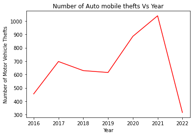

```python
# Extract all rows in the dataset that are related to vehicle theft.
theft_data = data.loc[data['Crime Name2'] == 'Motor Vehicle Theft']

# Use groupby and count functions to count thefts in a year.
theft_data_by_year = theft_data.copy().groupby(theft_data['year'], as_index=True, group_keys=True).count()
theft_data_count = theft_data_by_year[['Incident ID']].reset_index()
theft_data_count = theft_data_count.rename(index=str, columns={'Incident ID' : 'Count'})
print(theft_data_count)

# Let's plot!! Put data in plot and label the graph accordingly.
plt.plot(theft_data_count['year'], theft_data_count['Count'], color='red')
plt.title('Number of Auto mobile thefts Vs Year')
plt.xlabel('Year')
plt.ylabel('Number of Motor Vehicle Thefts')

plt.show()
```

```python
theft_mean = theft_data_count['Count'].mean()
theft_std = theft_data_count['Count'].std()
print("Mean: " + str(theft_mean) + " theft/year")
print("Standard Deviation: " + str(theft_std))
```

```
Mean: 662.2857142857143 theft/year
Standard Deviation: 244.589938663139
```

# 2.2: Drug Violation

Like the previous part, this is also relatively simple. To achieve our objective all we need to do is use Pandas.loc() to filter the rows that are related to drug violation and Pandas.groupby() to group the fitered datset by year so that we can visualize it using matplotlib.

```
   year  Count
0  2016    920
1  2017   1985
2  2018   1928
3  2019   1376
4  2020    548
5  2021    247
6  2022    163
```

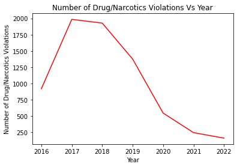

```python
# Extract all rows in the dataset that are related to drug violation.
drug_data = data.loc[data['Crime Name2'] == 'Drug/Narcotic Violations']

# Use groupby and count functions to count violations in a year.
drug_data_by_year = drug_data.copy().groupby(drug_data['year'], as_index=True, group_keys=True).count()
drug_data_count = drug_data_by_year[['Incident ID']].reset_index()
drug_data_count = drug_data_count.rename(index=str, columns={'Incident ID' : 'Count'})
print(drug_data_count)

# Let's plot!! Put data in plot and label the graph accordingly.
plt.plot(drug_data_count['year'], drug_data_count['Count'], color='red')
plt.ylabel('Number of Drug/Narcotics Violations')
plt.xlabel('Year')
plt.title('Number of Drug/Narcotics Violations Vs Year')
plt.show()
```

From the plot above, it is observed that the number of vilations seems to have decreased by year in recent years. The number of drug abuses were relatively high in the period from 2016 to 2019, where 2017 served as the year with highest recorded cases of 1985. After that, the number seems to be decreasing and has acehived a new low of 163 (the smallest yet) in 2022. Compared to the previous graph, there exists a noticeable trend after 2017 which warrants further study into the topic. Let's create some small statistical data on it as well.

```python
drug_mean = drug_data_count['Count'].mean()
drug_std = drug_data_count['Count'].std()
print("Mean: " + str(drug_mean) + " violation/year")
print("Standard Deviation: " + str(drug_std))
```

```
Mean: 1023.8571428571429 violation/year
Standard Deviation: 757.9668921026891
```

# 2.3: Assault

Like 2.2, this is also relatively simple. To achieve our objective all we need to do is use Pandas.loc() to filter the rows that are related to assault and Pandas.groupby() to group the fitered datset by year so that we can visualize it using matplotlib. Please note that assault herein refers to 'simple assault', meaning a person commits a simple assault if he attempts, to put another in fear of imminent serious bodily injury and not necessarily commits the deed.

```
   year  Count
0  2016    768
1  2017   1359
2  2018   1320
3  2019   1140
4  2020    939
5  2021   1004
6  2022    364
```

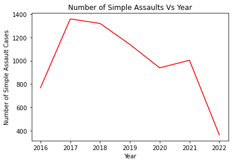

```python
# Extract all rows in the dataset that are related to simple assault.
as_data = data.loc[data['Crime Name2'] == 'Simple Assault']

# Use groupby and count functions to count assaults in a year.
as_data_by_year = as_data.copy().groupby(as_data['year'], as_index=True, group_keys=True).count()
as_data_count = as_data_by_year[['Incident ID']].reset_index()
as_data_count = as_data_count.rename(index=str, columns={'Incident ID' : 'Count'})
print(as_data_count)

# Let's plot!! Put data in plot and label the graph accordingly.
plt.plot(as_data_count['year'], as_data_count['Count'], color='red')
plt.ylabel('Number of Simple Assault Cases')
plt.xlabel('Year')
plt.title('Number of Simple Assaults Vs Year')
plt.show()
```

```python
as_mean = as_data_count['Count'].mean()
as_std = as_data_count['Count'].std()
print("Mean: " + str(as_mean) + " assaults/year")
print("Standard Deviation: " + str(as_std))
```

```
Mean: 984.8571428571429 assaults/year
Standard Deviation: 344.3188583137383
```

# 2.4: Vandalism

Lastly, this portion is also relatively simple and will excute the same commands as the previous steps. To achieve our objective all we need to do is use Pandas.loc() to filter the rows that are related to vandalism and Pandas.groupby() to group the fitered datset by year so that we can visualize it using matplotlib.

```
   year  Count
0  2016   1267
1  2017   2426
2  2018   1962
3  2019   1763
4  2020   2069
5  2021   1827
6  2022    632
```

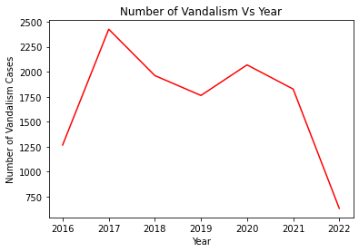

```python
# Extract all rows in the dataset that are related to vandalism.
vand_data = data.loc[data['Crime Name2'] == 'Destruction/Damage/Vandalism of Property']

# Use groupby and count functions to count assaults in a year.
vand_data_by_year = vand_data.copy().groupby(vand_data['year'], as_index=True, group_keys=True).count()
vand_data_count = vand_data_by_year[['Incident ID']].reset_index()
vand_data_count = vand_data_count.rename(index=str, columns={'Incident ID' : 'Count'})
print(vand_data_count)

# Let's plot!! Put data in plot and label the graph accordingly.
plt.plot(vand_data_count['year'], vand_data_count['Count'], color='red')
plt.ylabel('Number of Vandalism Cases')
plt.xlabel('Year')
plt.title('Number of Vandalism Vs Year')
plt.show()
```

```python
vand_mean = vand_data_count['Count'].mean()
vand_std = vand_data_count['Count'].std()
print("Mean: " + str(vand_mean) + " assaults/year")
print("Standard Deviation: " + str(vand_std))
```

```
Mean: 1706.5714285714287 assaults/year
Standard Deviation: 588.7542942922955
```

# Combine part 2

Now that we have individaully filter and graphed various criminal activities reported in Montgomery, MD by year; let's combine each subplot so that we can draw conclusion amongst each types of incident and possible find some trend that explains the graphs above. Although we have obsereved non-trendy graphs eariler on, we can observe that the combined graph will showcase a downward trend in recents years (2021-2022).

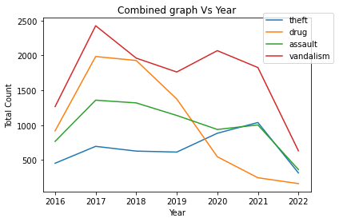

```python
# Let's plot!! Put data in plot and label the graph accordingly.
plt.plot(theft_data_count['year'], theft_data_count['Count'], label ='theft')
plt.plot(drug_data_count['year'], drug_data_count['Count'], label ='drug')
plt.plot(as_data_count['year'], as_data_count['Count'], label ='assault')
plt.plot(vand_data_count['year'], vand_data_count['Count'], label ='vandalism')
plt.ylabel('Total Count')
plt.xlabel('Year')
plt.title('Combined graph Vs Year')
plt.legend(bbox_to_anchor=(1.1, 1.05))
plt.show()
```

Based on the graph above we can concur that our hypothesis above was partially correct. We can observe that the graph doesn't have a noticeable trend however it has some pattern that are intersting. For example, there is been a increase in crime from 2016 to 2017 and a decrease between 2021 and 2022. This warrants further study into the topic? Has is there some outside factor that has this effect? Will we find a similar trend for all other crime types?

Below is a interactive map, created using Folium, that pinpoints the location of each type of incident in the county based on latitude and longitude and year. Since the dataset is large we have restricted the amount of rows we are going to plot to avoid congestion. You can learn more about the api at: https://python-visualization.github.io/folium/.

This the color key followed for year:

- 2016: Red
- 2017: Blue
- 2018: Green
- 2019: Pink
- 2020: Purple
- 2021: Orange
- 2022: Gray

# Motor Vehicle Theft Map

```python
# Create a Folium map centered at Montogomery County, MD.
map_osm = fo.Map(location=[39.15, -77.24], zoom_start=13)

# Get the first 200 rows to plot. Plotting everything will congest the map.
theft_sub = theft_data.head(200)
theft_data_2016 = theft_sub.loc[data['year'] == 2016]
theft_data_2017 = theft_sub.loc[data['year'] == 2017]
theft_data_2018 = theft_sub.loc[data['year'] == 2018]
theft_data_2019 = theft_sub.loc[data['year'] == 2019]
theft_data_2020 = theft_sub.loc[data['year'] == 2020]
theft_data_2021 = theft_sub.loc[data['year'] == 2021]
theft_data_2022 = theft_sub.loc[data['year'] == 2022]

# For each sub dataset above plot them with a unique color based on year. The Folium.Marker() method places a pin at a given lat. and long.
# and can color each pin uniquely.
for index, incident in theft_data_2016.iterrows():
    fo.Marker(location=[incident["Latitude"], incident["Longitude"]],icon=fo.Icon(color='red')).add_to(map_osm)
for index, incident in theft_data_2017.iterrows():
    fo.Marker(location=[incident["Latitude"], incident["Longitude"]],icon=fo.Icon(color='blue')).add_to(map_osm)
for index, incident in theft_data_2018.iterrows():
    fo.Marker(location=[incident["Latitude"], incident["Longitude"]],icon=fo.Icon(color='green')).add_to(map_osm)
for index, incident in theft_data_2019.iterrows():
    fo.Marker(location=[incident["Latitude"], incident["Longitude"]],icon=fo.Icon(color='pink')).add_to(map_osm)
for index, incident in theft_data_2020.iterrows():
    fo.Marker(location=[incident["Latitude"], incident["Longitude"]],icon=fo.Icon(color='purple')).add_to(map_osm)
for index, incident in theft_data_2021.iterrows():
    fo.Marker(location=[incident["Latitude"], incident["Longitude"]],icon=fo.Icon(color='orange')).add_to(map_osm)
for index, incident in theft_data_2022.iterrows():
    fo.Marker(location=[incident["Latitude"], incident["Longitude"]],icon=fo.Icon(color='gray')).add_to(map_osm)

map_osm
```

Make this Notebook Trusted to load map: File -> Trust Notebook

[interactive chart not shown]

# Drug Violation Map

```python
# Create a Folium map centered at Montogomery County, MD.
map_osm = fo.Map(location=[39.15, -77.24], zoom_start=13)

# Get the first 200 rows to plot. Plotting everything will congest the map.
drug_sub = drug_data.head(200)
drug_sub_2016 = drug_sub.loc[data['year'] == 2016]
drug_sub_2017 = drug_sub.loc[data['year'] == 2017]
drug_sub_2018 = drug_sub.loc[data['year'] == 2018]
drug_sub_2019 = drug_sub.loc[data['year'] == 2019]
drug_sub_2020 = drug_sub.loc[data['year'] == 2020]
drug_sub_2021 = drug_sub.loc[data['year'] == 2021]
drug_sub_2022 = drug_sub.loc[data['year'] == 2022]

# For each sub dataset above plot them with a unique color based on year. The Folium.Marker() method places a pin at a given lat. and long.
# and can color each pin uniquely.
for index, incident in drug_sub_2016.iterrows():
    fo.Marker(location=[incident["Latitude"], incident["Longitude"]],icon=fo.Icon(color='red')).add_to(map_osm)
for index, incident in drug_sub_2017.iterrows():
    fo.Marker(location=[incident["Latitude"], incident["Longitude"]],icon=fo.Icon(color='blue')).add_to(map_osm)
for index, incident in drug_sub_2018.iterrows():
    fo.Marker(location=[incident["Latitude"], incident["Longitude"]],icon=fo.Icon(color='green')).add_to(map_osm)
for index, incident in drug_sub_2019.iterrows():
    fo.Marker(location=[incident["Latitude"], incident["Longitude"]],icon=fo.Icon(color='pink')).add_to(map_osm)
for index, incident in drug_sub_2020.iterrows():
    fo.Marker(location=[incident["Latitude"], incident["Longitude"]],icon=fo.Icon(color='purple')).add_to(map_osm)
for index, incident in drug_sub_2021.iterrows():
    fo.Marker(location=[incident["Latitude"], incident["Longitude"]],icon=fo.Icon(color='orange')).add_to(map_osm)
for index, incident in drug_sub_2022.iterrows():
    fo.Marker(location=[incident["Latitude"], incident["Longitude"]],icon=fo.Icon(color='gray')).add_to(map_osm)

map_osm
```

Make this Notebook Trusted to load map: File -> Trust Notebook

[interactive chart not shown]

# Simple Assaults Map

```python
# Create a Folium map centered at Montogomery County, MD.
map_osm = fo.Map(location=[39.15, -77.24], zoom_start=13)

# Get the first 200 rows to plot. Plotting everything will congest the map.
as_sub = as_data.head(200)
as_sub_2016 = as_sub.loc[data['year'] == 2016]
as_sub_2017 = as_sub.loc[data['year'] == 2017]
as_sub_2018 = as_sub.loc[data['year'] == 2018]
as_sub_2019 = as_sub.loc[data['year'] == 2019]
as_sub_2020 = as_sub.loc[data['year'] == 2020]
as_sub_2021 = as_sub.loc[data['year'] == 2021]
as_sub_2022 = as_sub.loc[data['year'] == 2022]

# For each sub dataset above plot them with a unique color based on year. The Folium.Marker() method places a pin at a given lat. and long.
# and can color each pin uniquely.
for index, incident in as_sub_2016.iterrows():
    fo.Marker(location=[incident["Latitude"], incident["Longitude"]],icon=fo.Icon(color='red')).add_to(map_osm)
for index, incident in as_sub_2017.iterrows():
    fo.Marker(location=[incident["Latitude"], incident["Longitude"]],icon=fo.Icon(color='blue')).add_to(map_osm)
for index, incident in as_sub_2018.iterrows():
    fo.Marker(location=[incident["Latitude"], incident["Longitude"]],icon=fo.Icon(color='green')).add_to(map_osm)
for index, incident in as_sub_2019.iterrows():
    fo.Marker(location=[incident["Latitude"], incident["Longitude"]],icon=fo.Icon(color='pink')).add_to(map_osm)
for index, incident in as_sub_2020.iterrows():
    fo.Marker(location=[incident["Latitude"], incident["Longitude"]],icon=fo.Icon(color='purple')).add_to(map_osm)
for index, incident in as_sub_2021.iterrows():
    fo.Marker(location=[incident["Latitude"], incident["Longitude"]],icon=fo.Icon(color='orange')).add_to(map_osm)
for index, incident in as_sub_2022.iterrows():
    fo.Marker(location=[incident["Latitude"], incident["Longitude"]],icon=fo.Icon(color='gray')).add_to(map_osm)

map_osm
```

Make this Notebook Trusted to load map: File -> Trust Notebook

[interactive chart not shown]

# Vandalisms Map

```python
# Create a Folium map centered at Montogomery County, MD.
map_osm = fo.Map(location=[39.15, -77.24], zoom_start=13)

# Get the first 200 rows to plot. Plotting everything will congest the map.
vand_sub = vand_data.head(200)
vand_sub_2016 = vand_sub.loc[data['year'] == 2016]
vand_sub_2017 = vand_sub.loc[data['year'] == 2017]
vand_sub_2018 = vand_sub.loc[data['year'] == 2018]
vand_sub_2019 = vand_sub.loc[data['year'] == 2019]
vand_sub_2020 = vand_sub.loc[data['year'] == 2020]
vand_sub_2021 = vand_sub.loc[data['year'] == 2021]
vand_sub_2022 = vand_sub.loc[data['year'] == 2022]

# For each sub dataset above plot them with a unique color based on year. The Folium.Marker() method places a pin at a given lat. and long.
# and can color each pin uniquely.
for index, incident in vand_sub_2016.iterrows():
    fo.Marker(location=[incident["Latitude"], incident["Longitude"]],icon=fo.Icon(color='red')).add_to(map_osm)
for index, incident in vand_sub_2017.iterrows():
    fo.Marker(location=[incident["Latitude"], incident["Longitude"]],icon=fo.Icon(color='blue')).add_to(map_osm)
for index, incident in vand_sub_2018.iterrows():
    fo.Marker(location=[incident["Latitude"], incident["Longitude"]],icon=fo.Icon(color='green')).add_to(map_osm)
for index, incident in vand_sub_2019.iterrows():
    fo.Marker(location=[incident["Latitude"], incident["Longitude"]],icon=fo.Icon(color='pink')).add_to(map_osm)
for index, incident in vand_sub_2020.iterrows():
    fo.Marker(location=[incident["Latitude"], incident["Longitude"]],icon=fo.Icon(color='purple')).add_to(map_osm)
for index, incident in vand_sub_2021.iterrows():
    fo.Marker(location=[incident["Latitude"], incident["Longitude"]],icon=fo.Icon(color='orange')).add_to(map_osm)
for index, incident in vand_sub_2022.iterrows():
    fo.Marker(location=[incident["Latitude"], incident["Longitude"]],icon=fo.Icon(color='gray')).add_to(map_osm)

map_osm
```

Make this Notebook Trusted to load map: File -> Trust Notebook

[interactive chart not shown]

Please note that since we are restircting the number of rows we graph, the map does not portray all the incident for all years. You can change by increasing the number in the .head() function in code snippets above. But for efficiency sake, we will keep the number to 200 for now.

# PART 3: Hypothesis Testing

Now that we have our analysis done we can start doing linear regression and start testing our hypothesis. When doing a linear regression, we're taking data that is already there and predicting future data base on the patterns of the data we already have. We are going to take a linear regression of all four types however for the sake of hypothesis testing we wont't be performing tests on all four crime types. Note testing all four crime types will make this tutorial very long and hard to follow through; however you can do it if you are intestered. Simply follow the steps below to generate and test your own hypothesis.

# 3.1: Linear Regression

This process is relatively simple. Essentially we just need to convert our data into lists that can be passed into the Numpy.polyfit() function to get a linear regression. After that we will just plot the regression obtained using matplotlib. You can learn more about Numpy at: https://numpy.org.

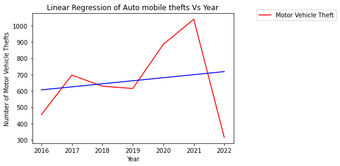

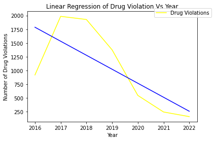

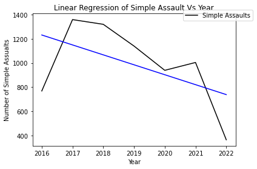

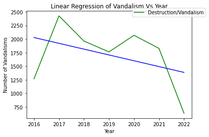

```python
# Extract the required theft data from pandas dataframe into a list so that they can be
# passed into the polyfit function.
count_arr = []
count_arr.extend(theft_data_count['Count'].to_numpy().tolist())
year_arr = []
year_arr.extend(theft_data_count['year'].to_numpy().tolist())

# Get the regression line function using numpy.polyfit().
func = np.polyfit(year_arr, count_arr, 1)
regline_coords = [func[0] * i + func[1] for i in year_arr]

# Plot the regression line coordinates.
plt.plot(theft_data_count['year'], theft_data_count['Count'], color='red', label='Motor Vehicle Theft')
plt.plot(year_arr,regline_coords, 'b')
plt.ylabel('Number of Motor Vehicle Thefts')
plt.xlabel('Year')
plt.title('Linear Regression of Auto mobile thefts Vs Year')
plt.legend(bbox_to_anchor=(1.1, 1.05))
plt.show()


# Extract the required drug violation data from pandas dataframe into a list so that they can be
# passed into the polyfit function.
count_arr = []
count_arr.extend(drug_data_count['Count'].to_numpy().tolist())
year_arr = []
year_arr.extend(drug_data_count['year'].to_numpy().tolist())

# Get the regression line function using numpy.polyfit().
func = np.polyfit(year_arr, count_arr, 1)
regline_coords = [func[0] * i + func[1] for i in year_arr]

# Plot the regression line coordinates.
plt.plot(drug_data_count['year'], drug_data_count['Count'], color='yellow', label='Drug Violations')
plt.plot(year_arr,regline_coords, 'b')
plt.ylabel('Number of Drug Violations')
plt.xlabel('Year')
plt.title('Linear Regression of Drug Violation Vs Year')
plt.legend(bbox_to_anchor=(1.1, 1.05))
plt.show()


# Extract the required simple assault data from pandas dataframe into a list so that they can be
# passed into the polyfit function.
count_arr = []
count_arr.extend(as_data_count['Count'].to_numpy().tolist())
year_arr = []
year_arr.extend(as_data_count['year'].to_numpy().tolist())

# Get the regression line function using numpy.polyfit().
func = np.polyfit(year_arr, count_arr, 1)
regline_coords = [func[0] * i + func[1] for i in year_arr]

# Plot the regression line coordinates.
plt.plot(as_data_count['year'], as_data_count['Count'], color='black', label='Simple Assaults')
plt.plot(year_arr,regline_coords, 'b')
plt.ylabel('Number of Simple Assualts')
plt.xlabel('Year')
plt.title('Linear Regression of Simple Assault Vs Year')
plt.legend(bbox_to_anchor=(1.1, 1.05))
plt.show()


# Extract the required simple assault data from pandas dataframe into a list so that they can be
# passed into the polyfit function.
count_arr = []
count_arr.extend(vand_data_count['Count'].to_numpy().tolist())
year_arr = []
year_arr.extend(vand_data_count['year'].to_numpy().tolist())

# Get the regression line function using numpy.polyfit().
func = np.polyfit(year_arr, count_arr, 1)
regline_coords = [func[0] * i + func[1] for i in year_arr]

# Plot the regression line coordinates.
plt.plot(vand_data_count['year'], vand_data_count['Count'], color='green', label='Destruction/Vandalism')
plt.plot(year_arr,regline_coords, 'b')
plt.ylabel('Number of Vandalisms')
plt.xlabel('Year')
plt.title('Linear Regression of Vandalism Vs Year')
plt.legend(bbox_to_anchor=(1.1, 1.05))
plt.show()
```

# 3.2: Hypothesis Testing

```python
# Create a regression using statsmodel.fit() and as_data_count dataset.
as_reg = st(formula='Count ~ year', data=as_data_count).fit()

# summary() provides the regression details.
print("Simple Assualts Regression.")
print(as_reg.summary())

# Create a regression using statsmodel.fit() and vand_data_count dataset.
vand_reg = st(formula='Count ~ year', data=vand_data_count).fit()
print("Vandalism Regression.")
print(vand_reg.summary())
```

```
Simple Assualts Regression.
                            OLS Regression Results
==============================================================================
Dep. Variable:                  Count   R-squared:                       0.266
Model:                            OLS   Adj. R-squared:                  0.120
Method:                 Least Squares   F-statistic:                     1.815
Date:                Mon, 16 May 2022   Prob (F-statistic):              0.236
Time:                        14:31:06   Log-Likelihood:                -49.200
No. Observations:                   7   AIC:                             102.4
Df Residuals:                       5   BIC:                             102.3
Df Model:                           1
Covariance Type:            nonrobust
==============================================================================
                 coef    std err          t      P>|t|      [0.025      0.975]
------------------------------------------------------------------------------
Intercept    1.67e+05   1.23e+05      1.355      0.233    -1.5e+05    4.84e+05
year         -82.2500     61.057     -1.347      0.236    -239.202      74.702
==============================================================================
Omnibus:                          nan   Durbin-Watson:                   1.555
Prob(Omnibus):                    nan   Jarque-Bera (JB):                1.141
Skew:                          -0.818   Prob(JB):                        0.565
Kurtosis:                       1.889   Cond. No.                     2.04e+06
==============================================================================

Notes:
[1] Standard Errors assume that the covariance matrix of the errors is correctly specified.
[2] The condition number is large, 2.04e+06. This might indicate that there are
strong multicollinearity or other numerical problems.
Vandalism Regression.
                            OLS Regression Results
==============================================================================
Dep. Variable:                  Count   R-squared:                       0.154
Model:                            OLS   Adj. R-squared:                 -0.015
Method:                 Least Squares   F-statistic:                    0.9111
Date:                Mon, 16 May 2022   Prob (F-statistic):              0.384
Time:                        14:31:06   Log-Likelihood:                -53.453
No. Observations:                   7   AIC:                             110.9
Df Residuals:                       5   BIC:                             110.8
Df Model:                           1
Covariance Type:            nonrobust
==============================================================================
                 coef    std err          t      P>|t|      [0.025      0.975]
------------------------------------------------------------------------------
Intercept   2.177e+05   2.26e+05      0.962      0.380   -3.64e+05       8e+05
year        -107.0000    112.097     -0.955      0.384    -395.156     181.156
==============================================================================
Omnibus:                          nan   Durbin-Watson:                   1.769
Prob(Omnibus):                    nan   Jarque-Bera (JB):                0.969
Skew:                          -0.674   Prob(JB):                        0.616
Kurtosis:                       1.773   Cond. No.                     2.04e+06
==============================================================================

Notes:
[1] Standard Errors assume that the covariance matrix of the errors is correctly specified.
[2] The condition number is large, 2.04e+06. This might indicate that there are
strong multicollinearity or other numerical problems.
```

Let's perform F-Test.....

```python
as_reg_test = api.stats.anova_lm(as_reg, typ=2)
vand_reg_test = api.stats.anova_lm(vand_reg, typ=2)
print(as_reg_test)
print(vand_reg_test)
```

```
                 sum_sq   df         F    PR(>F)
year      189421.750000  1.0  1.814694  0.235775
Residual  521911.107143  5.0       NaN       NaN
                sum_sq   df         F    PR(>F)
year      3.205720e+05  1.0  0.911121  0.383653
Residual  1.759218e+06  5.0       NaN       NaN
```

# Part 4: Conclusion

The purpose of this study is to gain insight on the crime rates in Montogomery County, MD. As a resident of the county, it is very important for me to be aware of the activities going around my residents. Although, reading some wiki-page can give a few facts it is still not effective. Rather trends and distribution can be effectively analyzed and communicated using data science. Our tutorial is an example of how we can use data science to help the audience be more aware about what is happening in our lives and around us. This tutorial serves not only to teach the audience about data science and its importance but also provide some mathematical insight into the crimes happeneing around us. Note, this regression models can be used to predict/estimate future values of each activities as well.

The dataset that we used contains a lot of information, not just the amount of recorded incidents or the date_time, but also the information of victims. Therefore we encourge the readers, if interested, to use the various data columsn to start a experiment of their own or even contiue this tutorial to answer some of the question listed above. With the tools that we used above, readers can perform more complex analysis and visualiztions with the rest of the open source data. The audience can also experiment with data of their liking since this the steps covered in this tutorial are generic and can be applied to any dataset for basic analysis.